# Activity9

Alexander Delargy

2023-11-29

## Collatz Conjecture

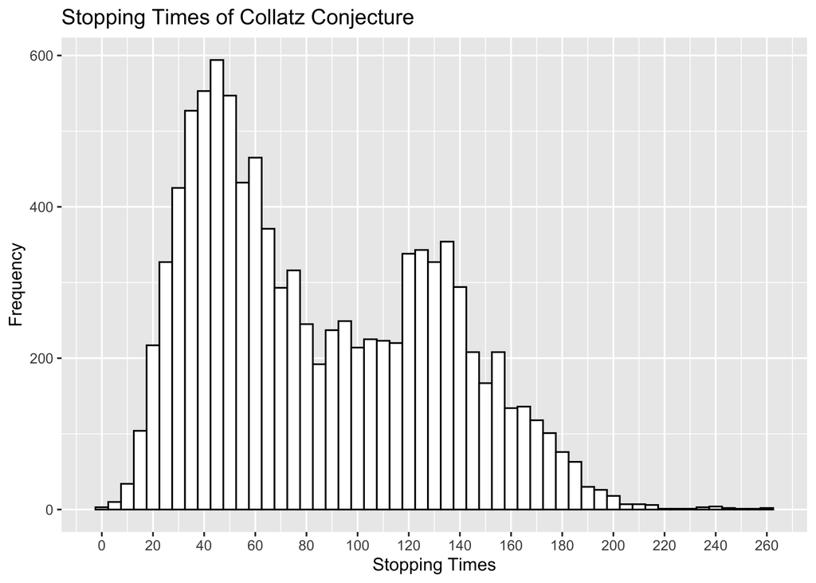

The above histogram demonstrates the distribution of Stopping Times among the first 10,000 integers. It has peaks around 50 and 130. This shows that a large number of the first 10,000 integers have stopping times from the Collatz Conjecture around these values.

## Diamonds

In this section, we will explore the diamonds data set from the ggplot2 package and try to find a relationship between different parameters of the diamond and the price of a diamond. The diamonds data set includes multiple parameters about its size, shape, quality, and price. Here is a preview of the data set:

Diamonds Data Set

| carat | cut | color | clarity | depth | table | price | x | y | z |
| --- | --- | --- | --- | --- | --- | --- | --- | --- | --- |
| 0.23 | Ideal | E | SI2 | 61.5 | 55 | 326 | 3.95 | 3.98 | 2.43 |
| 0.21 | Premium | E | SI1 | 59.8 | 61 | 326 | 3.89 | 3.84 | 2.31 |
| 0.23 | Good | E | VS1 | 56.9 | 65 | 327 | 4.05 | 4.07 | 2.31 |
| 0.29 | Premium | I | VS2 | 62.4 | 58 | 334 | 4.20 | 4.23 | 2.63 |
| 0.31 | Good | J | SI2 | 63.3 | 58 | 335 | 4.34 | 4.35 | 2.75 |
| 0.24 | Very Good | J | VVS2 | 62.8 | 57 | 336 | 3.94 | 3.96 | 2.48 |

### In particular, we will look at the relationship between Carat, Clarity, and Price.

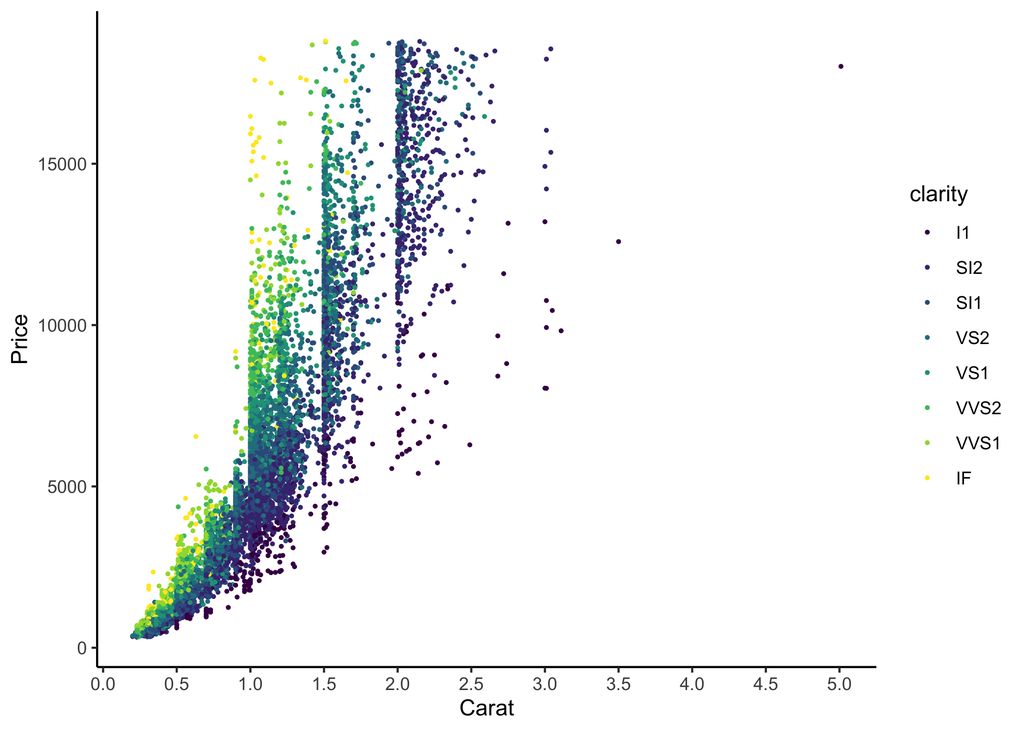

### Graph Interpretation

The above graph shows a positive correlation between Carat and Price. Generally, Price increases as Carat increases. The Clarity rating of the diamond is represented by the color of the glyph. The Clarity decreases as the glyph gets darker. From this scatter plot, we can see that for any given Carat value, the lighter glyphs tend to have a higher price. We can infer that there is a positive correlation between Clarity and Price based on this visualization.

### Summary Table

Diamonds by Clarity (Worst to Best)

| clarity | Average Price | Average Carat |
| --- | --- | --- |
| I1 | 3,924.17 | 1.28 |
| SI2 | 5,063.03 | 1.08 |
| SI1 | 3,996.00 | 0.85 |
| VS2 | 3,924.99 | 0.76 |
| VS1 | 3,839.46 | 0.73 |
| VVS2 | 3,283.74 | 0.60 |
| VVS1 | 2,523.11 | 0.50 |
| IF | 2,864.84 | 0.51 |

## Reflections

So far in this course I have learned about the RStudio environment, R programming language, and how to use R for data analysis and presentation. Specifically, I have learned how to import data through file uploads, web scraping, and loading data sets through packages in R. I have also learned how to utilize data wrangling packages such as dplyr and janitor to transform data into Tidy Data format. Lastly, I have learned how to create a myriad of visualizations that allow for visual analytics.

# Code Appendix

```r
knitr::opts_chunk$set(echo = TRUE, dpi = 300)
# This code chunk loads packages using the groundhog library

library(groundhog) # Use groundhog to roll back library versions to project date
pkgs <- c("tidyverse", "dplyr", "ggplot2", "janitor", "knitr", "kableExtra")
groundhog.library(pkgs, '2023-11-17')

# Function that returns the stopping time of the collatz conjecture given any positive integer
getCollatzStoppingTime <- function(n){
  if (n<=1){
    return (0) # Return 0 if n equal to one
  }
  else if (n %% 2 == 0){
    return (1 + getCollatzStoppingTime(n/2)) # Return 1 plus the count of n/2
  }
  else{
    return (1 + getCollatzStoppingTime(3*n+1)) # Return 1 plus the count of 3n+1
  }
}

# This code chunk creates a histogram of the stopping times of the collatz conjecture

# Create stopping time dataframe
Collatz <- data.frame(stoppingTimes=sapply(X=seq(1, 10000), FUN=getCollatzStoppingTime))

# Plot histogram
ggplot(Collatz) +
  aes(x=stoppingTimes) +
  geom_histogram(binwidth=5, color="black", fill="white") +
  labs(
    x = "Stopping Times",
    y = "Frequency",
    title = "Stopping Times of Collatz Conjecture"
  ) +
  scale_x_continuous(breaks = seq(0, max(Collatz$stoppingTimes), by = 20))
# This code chunk loads the diamonds dataset and displays it in a neat table

data(diamonds)
head(diamonds) %>%
  kable(
    caption = "Diamonds Data Set", # Add title
    booktabs = TRUE,
    align = c(rep("c", ncol(diamonds))) # Add alignment for 4 columns
  ) %>%
  kableExtra::kable_styling(
    bootstrap_options = c("striped", "condensed"), # Add striping for table
    font_size = 16
  )

# This code chunk Filters and selects a subset of rows and columns of the diamonds dataset

diamondsFiltered <- diamonds %>%
  select('price', 'carat', 'clarity') # Explore carat, clarity, and price

diamondsFilteredSample = slice_sample(diamondsFiltered, prop=0.3) # Sample is taken to avoid overplotting

# This code chunk Plots the price of the diamond vs the carat of the diamond

ggplot(data = diamondsFilteredSample) +
  aes(x = carat, y = price, color = clarity) + # Color represents clarity
  geom_point(
    shape = "circle small",
    size = 0.8 # Smaller points better show relationship
  ) +
  labs(
    x='Carat',
    y='Price'
  )+
  scale_x_continuous(breaks = seq(0, max(diamondsFilteredSample$carat), by = 0.5))+
  theme_classic()

# This code chunk produces a table of the average price and average carat of the diamonds by clarity classification.

# diamondsFiltered is used here instead of diamondsFilteredSample because we do not have to avoid overplotting
diamondsFiltered %>%
  group_by(clarity) %>%
  summarise(
    "Average Price" = round(mean(price), digits=2), # Average Price by Clarity
    "Average Carat" = round(mean(carat), digits=2) # Average Carat by Clarity
  ) %>%
  mutate(
    across(where(is.numeric), format, big.mark = ",") # Add commas for large numbers
  ) %>%
  kable(
    caption = "Diamonds by Clarity (Worst to Best)", # Add title
    booktabs = TRUE,
    align = c(rep("c", ncol(diamondsFiltered))) # Add alignment for 4 columns
  ) %>%
  kableExtra::kable_styling(
    bootstrap_options = c("striped", "condensed"), # Add striping for table
    font_size = 16
  )
```